# Group Project

Rish Pednekar, Sanjoli Srivastava, Braedon Dobryino

2023-04-21

## Loading dataset and libraries

```r
df <- read.csv("/cloud/project/Complete_DF")

library("ggplot2")
library("dplyr")
library("moderndive")
library("knitr")
library("gapminder")
library("skimr")
library("epiDisplay")
library("rockchalk")
library("infer")
library("ISLR")
library("car")
```

## EDA

```r
# convert data for correlation
data <- df
sapply(data, is.numeric)
```

```
##      country    continent   population      lifeexp    childmort       income
##        FALSE        FALSE         TRUE         TRUE         TRUE         TRUE
##    gdpcapita  chdperwoman  healthspend          co2        water   popdensity
##         TRUE         TRUE         TRUE         TRUE         TRUE         TRUE
##       murder greaterthan2
##         TRUE        FALSE
```

```r
data$country <- as.numeric(data$country)
data$continent<- as.numeric(data$continent)
data$greaterthan2 <- as.numeric(data$greaterthan2)
correlation_matrix <- as.data.frame(cor(data))
correlation_matrix
```

```
##              country continent   population    lifeexp   childmort      income
## country            1        NA           NA         NA          NA          NA
## continent         NA         1           NA         NA          NA          NA
## population        NA        NA  1.000000000  0.0297901 -0.03144044 -0.07155391
## lifeexp           NA        NA  0.029790103  1.0000000 -0.91406031  0.71092142
## childmort         NA        NA -0.031440438 -0.9140603  1.00000000 -0.63088658
## income            NA        NA -0.071553906  0.7109214 -0.63088658  1.00000000
## gdpcapita         NA        NA -0.050909966  0.6400103 -0.53310833  0.93544396
## chdperwoman       NA        NA -0.103890572 -0.7876055  0.85910987 -0.62746441
## healthspend       NA        NA -0.020499743  0.5822744 -0.47818273  0.83977983
## co2               NA        NA -0.007336614  0.5137558 -0.50767139  0.74276584
## water             NA        NA  0.046928750  0.8269762 -0.84841216  0.66281511
## popdensity        NA        NA  0.001758586  0.1423133 -0.11056955  0.32749296
## murder            NA        NA  0.001758586  0.1423133 -0.11056955  0.32749296
## greaterthan2      NA        NA  0.072706045  0.6224677 -0.58506705  0.60213917
##                gdpcapita chdperwoman healthspend          co2       water
## country               NA          NA          NA           NA          NA
## continent             NA          NA          NA           NA          NA
## population   -0.05090997  -0.1038906 -0.02049974 -0.007336614  0.04692875
## lifeexp       0.64001030  -0.7876055  0.58227436  0.513755765  0.82697624
## childmort    -0.53310833   0.8591099 -0.47818273 -0.507671392 -0.84841216
## income        0.93544396  -0.6274644  0.83977983  0.742765844  0.66281511
## gdpcapita     1.00000000  -0.5208082  0.94773773  0.612203650  0.55432074
## chdperwoman  -0.52080820   1.0000000 -0.47704677 -0.507379320 -0.87908315
## healthspend   0.94773773  -0.4770468  1.00000000  0.503621853  0.49423735
## co2           0.61220365  -0.5073793  0.50362185  1.000000000  0.54421009
## water         0.55432074  -0.8790832  0.49423735  0.544210091  1.00000000
## popdensity    0.20475354  -0.1459072  0.03666475  0.158974242  0.12510913
## murder        0.20475354  -0.1459072  0.03666475  0.158974242  0.12510913
## greaterthan2  0.57651090  -0.6869578  0.60233984  0.417221189  0.58610569
##                popdensity       murder greaterthan2
## country                NA           NA           NA
## continent              NA           NA           NA
## population    0.001758586  0.001758586   0.07270605
## lifeexp       0.142313287  0.142313287   0.62246768
## childmort    -0.110569550 -0.110569550  -0.58506705
## income        0.327492963  0.327492963   0.60213917
## gdpcapita     0.204753542  0.204753542   0.57651090
## chdperwoman  -0.145907164 -0.145907164  -0.68695777
## healthspend   0.036664746  0.036664746   0.60233984
## co2           0.158974242  0.158974242   0.41722119
## water         0.125109132  0.125109132   0.58610569
## popdensity    1.000000000  1.000000000   0.14041454
## murder        1.000000000  1.000000000   0.14041454
## greaterthan2  0.140414539  0.140414539   1.00000000
```

Within the correlation matrix, we can see that the values of any column or predictor that is greater than or equal to 0.5 must have notable impact on the life expectancy of any given country. Thus, those values are income (approx 0.71), gdpcapita (0.64 approx), healthspend (approx. 0.58), and water (approx 0.826). Also, we must do further investigation on why some values have negative correlation such as childmort (approx -0.91) and chdperwoman (approx. -0.787). We do not count the column greater than 2 because this was previously a TRUE or FALSE column which was converted into a numeric column thus it does not hold any numerical value.

## Graphing Main Predictors

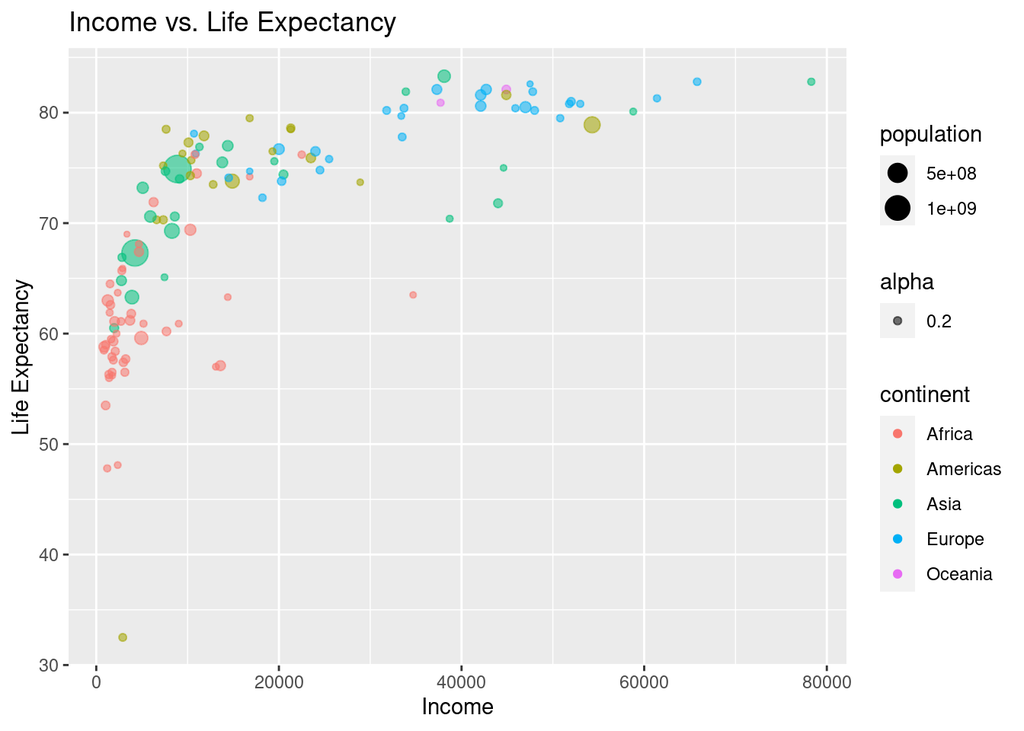

```r
ggplot(data = df, mapping = aes(income, lifeexp, size = population)) + geom_point(aes(color = continent, alpha = 0.2)) + labs(title = "Income vs. Life Expectancy", x = "Income", y = "Life Expectancy")
```

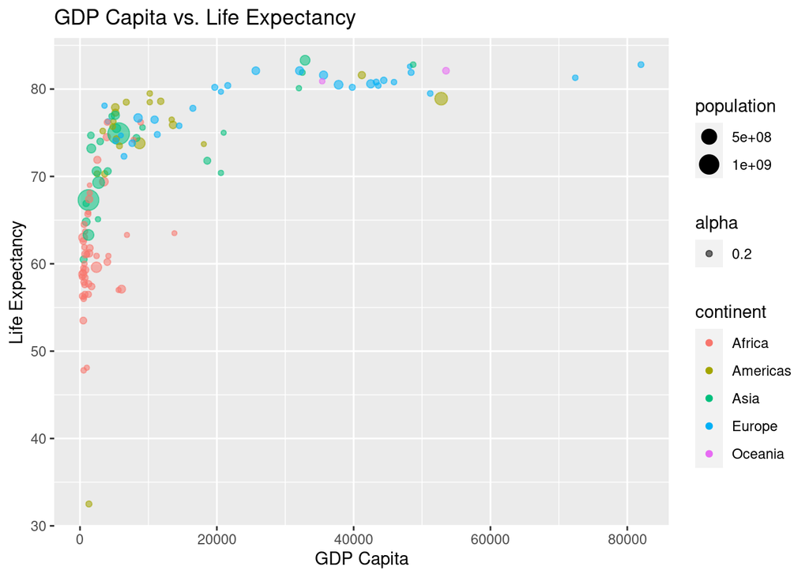

```r
ggplot(data = df, mapping = aes(gdpcapita, lifeexp, size = population)) + geom_point(aes(color = continent, alpha = 0.2)) + labs(title = "GDP Capita vs. Life Expectancy", x = "GDP Capita", y = "Life Expectancy")
```

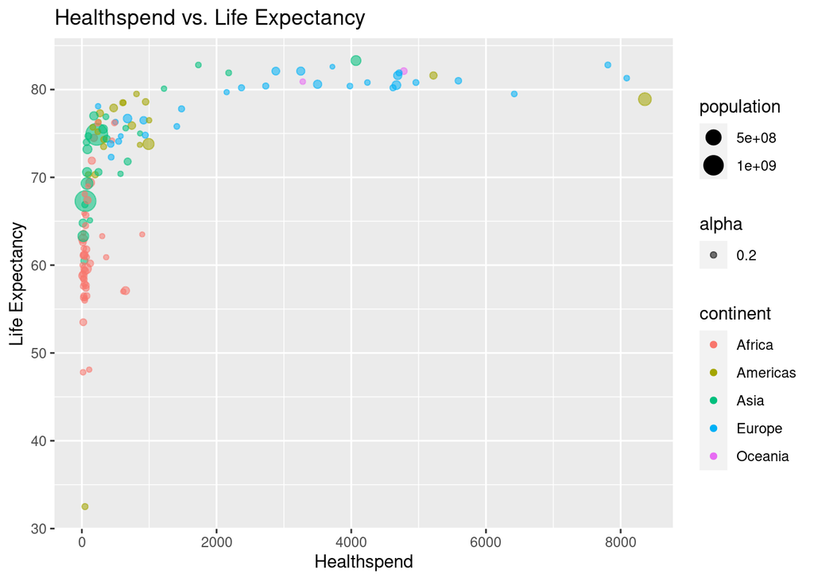

```r
ggplot(data = df, mapping = aes(healthspend, lifeexp, size = population)) + geom_point(aes(color = continent, alpha = 0.2)) + labs(title = "Healthspend vs. Life Expectancy", x = "Healthspend", y = "Life Expectancy")
```

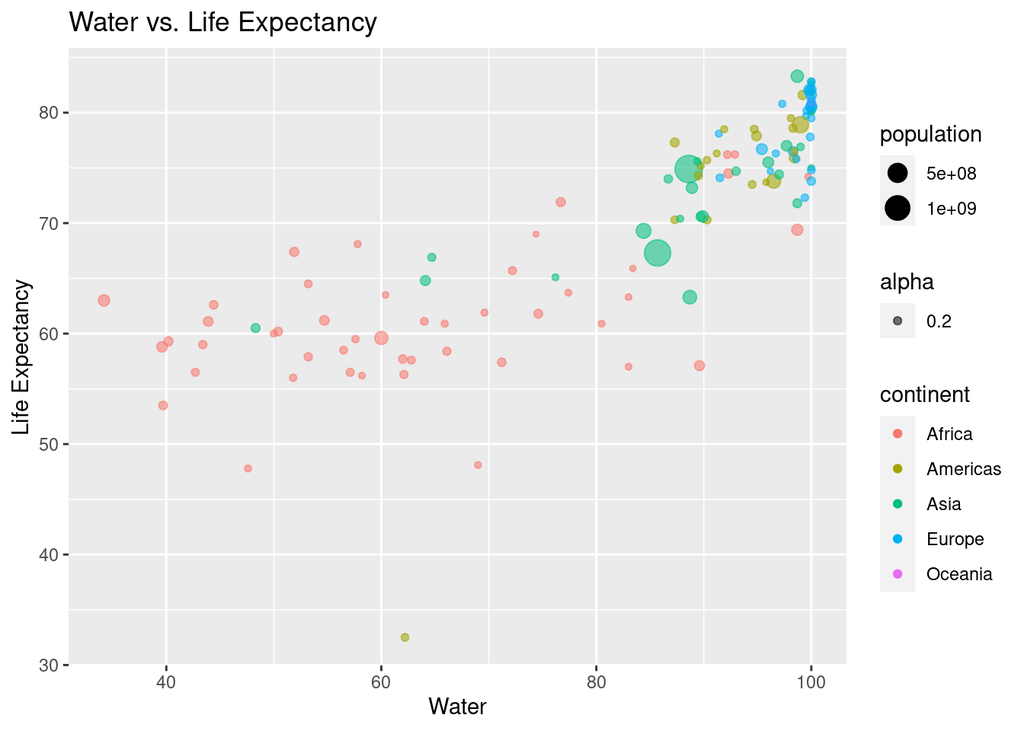

```r
ggplot(data = df, mapping = aes(water, lifeexp, size = population)) + geom_point(aes(color = continent, alpha = 0.2)) + labs(title = "Water vs. Life Expectancy", x = "Water", y = "Life Expectancy")
```

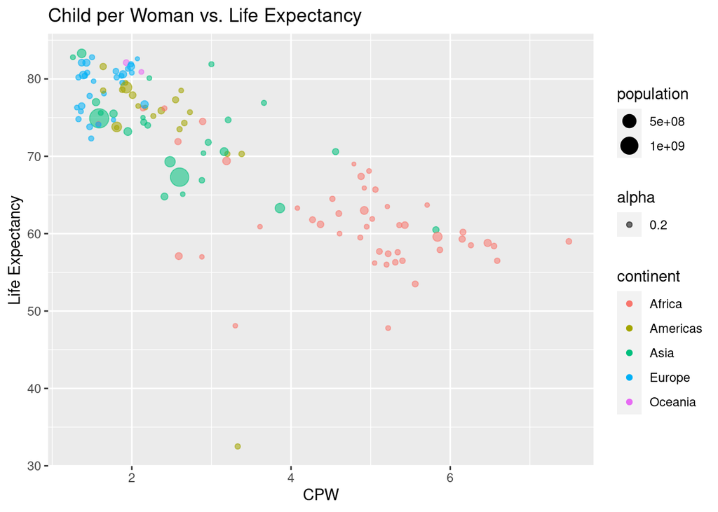

```r
# Change to a Multi-Factored Model
## Factor this if CPW = 1,2,3,4 etc.
ggplot(data = df, mapping = aes(chdperwoman, lifeexp, size = population)) + geom_point(aes(color = continent, alpha = 0.2)) + labs(title = "Child per Woman vs. Life Expectancy", x = "CPW", y = "Life Expectancy")
```

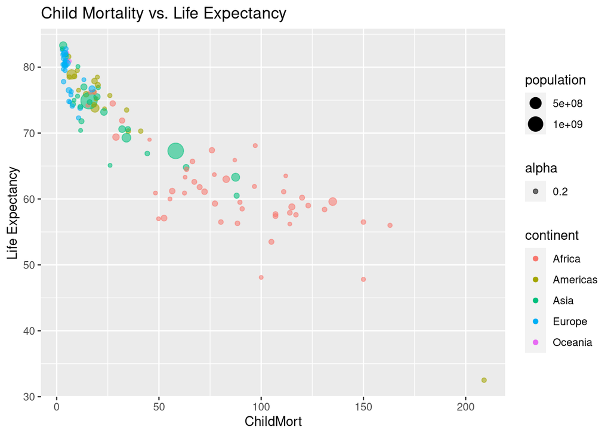

```r
# Change to a Multi-Factored Model
## Factor this if Mort = 0-50,50-100 etc.
ggplot(data = df, mapping = aes(childmort, lifeexp, size = population)) + geom_point(aes(color = continent, alpha = 0.2)) + labs(title = "Child Mortality vs. Life Expectancy", x = "ChildMort", y = "Life Expectancy")
```

Analyzing the graphs, we observed the following: - Income: As we can see the income for most of the African countries falls within the 0-20000 bracket of income where as other countries are more spread out. Thus, we would like to assign a categorical variable based on their income level and rank them in certain brackets. Additionally, we can see that the graph is right-skewed, indicating the average income is below the mean.

- GDP capita: Similar to the income graph, this graph also shows that the GDP capita for all of the African countries falls in the 0-20000 bracket. Additionally, European countries seem to have the highest values in terms of this variable. Also, there are two significant outliers in this graph with Europe being the highest and Americas being the lowest (they can be seen in the top right and bottom left corners respectively). For this graph, the skewness is similar to income, meaning more than half of the families earn below the average gdp per capita.
- Health spend: Based on the graph, we can see that African countries seem to be on the lower end of this variable almost entirely. European countries are much more spread out, and American countries seem to be either mainly on the low end or high end of health spending as both of the outliers in the graph are American countries. Additionally, Asia also seems to be on the lower end of health spending. This is also an extreme case of right-skewed distribution, and a significant majority spend less than a few hundred on their family healthcare.

-Water: Based on the graph, there seems to be a positive correlation between life expectancy and water. In this graph in particular, African countries seem to have a more spread-out distribution whereas European countries seem to clustering towards the higher end. Additionally, Asian countries appear to have higher overall water usage, since there are larger clusters. There is one notable outlier from the Americas that can be seen at the bottom of the graph. Overall, this variable seems significant enough to be included in our regression model.

# Making the Model Description

```r
model1 <- lm(data=df, lifeexp ~  income+healthspend*gdpcapita+chdperwoman*childmort+water)

get_regression_table(model1)
```

```
## # A tibble: 9 × 7
##   term                  estimate std_error statistic p_value lower_ci upper_ci
##   <chr>                    <dbl>     <dbl>     <dbl>   <dbl>    <dbl>    <dbl>
## 1 intercept               71.9       3.77      19.1    0       64.5     79.4
## 2 income                   0         0         -1.68   0.097    0        0
## 3 healthspend              0         0.001      0.17   0.865   -0.001    0.001
## 4 gdpcapita                0         0          2.27   0.025    0        0
## 5 chdperwoman             -1.12      0.524     -2.13   0.036   -2.15    -0.077
## 6 childmort               -0.304     0.027    -11.3    0       -0.357   -0.251
## 7 water                    0.094     0.033      2.85   0.005    0.029    0.16
## 8 healthspend:gdpcapita    0         0         -1.40   0.165    0        0
## 9 chdperwoman:childmort    0.034     0.006      5.94   0        0.023    0.046
```

```r
get_regression_summaries(model1)
```

```
## # A tibble: 1 × 9
##   r_squared adj_r_squared   mse  rmse sigma statistic p_value    df  nobs
##       <dbl>         <dbl> <dbl> <dbl> <dbl>     <dbl>   <dbl> <dbl> <dbl>
## 1     0.908         0.902  8.44  2.91  3.02      141.       0     8   123
```

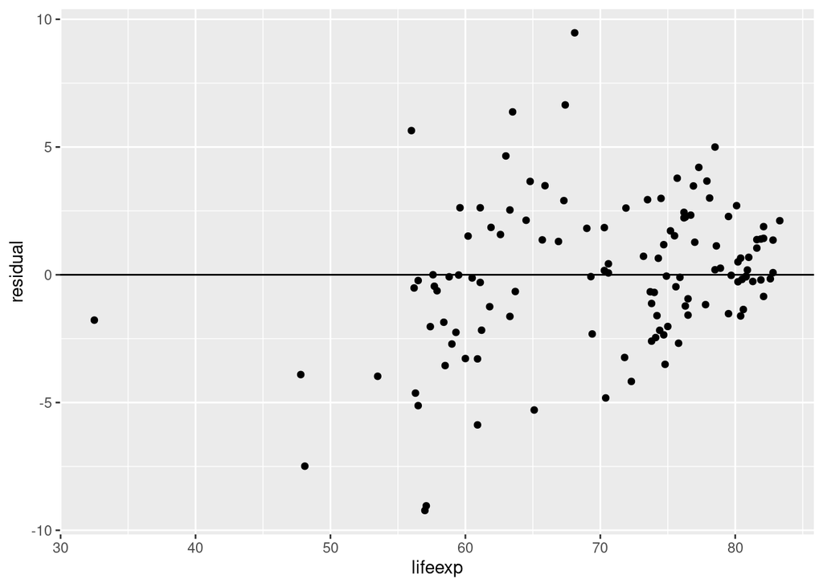

```r
points <- get_regression_points(model1)
ggplot(data = points, mapping = aes(lifeexp, residual)) + geom_point() + geom_hline(yintercept = 0)
```

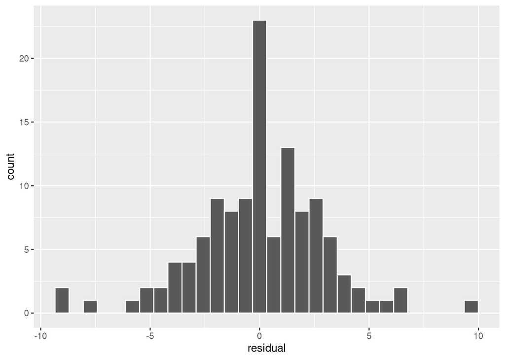

```r
ggplot(data = points, mapping = aes(residual)) + geom_histogram(color = "white")
```

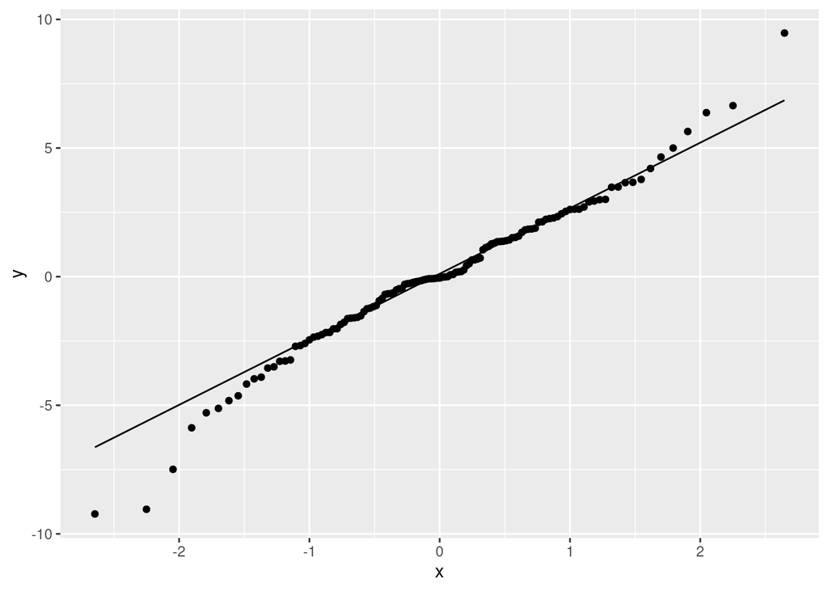

```r
ggplot(data = points, aes(sample = residual)) + stat_qq() + stat_qq_line()
```

## Mutating the Model

```r
mutated_df <- df
mutated_df$income_level <- cut(mutated_df$income, breaks = c(-Inf, 20000, 40000, 60000, Inf), labels = c(1, 2, 3, 4))
# Category 1 -> Represents all income levels <= 20000
# Category 2 -> Represents all income levels > 20000 & <= 40000
# Category 3 -> Represents all income levels >= 40000 & <= 60000
# Category 4 -> Represents all income levels > 60000

mutated_df$amountchildren <- cut(mutated_df$chdperwoman, breaks = c(-Inf, 2, 4, 6, Inf), labels = c(1, 2, 3, 4))
# Category 1 -> Represents amount of children <= 2
# Category 2 -> Represents amount of children > 2 & <= 4
# Category 3 -> Represents amount of children > 4 & <= 6
# Category 4 -> Represents amount of children > 6


mutated_df$mort_level <- cut(mutated_df$childmort, breaks = c(-Inf, 50, 100, 150, Inf), labels = c(1, 2, 3, 4))
# Category 1 -> Represents child mortality <= 50
# Category 2 -> Represents amount of children > 50 & <= 100
# Category 3 -> Represents amount of children > 100 & <= 150
# Category 4 -> Represents amount of children > 150
```

## Creating new correlation matrix

```r
# Checking correlation of newly created rows
data_matrix <- mutated_df

data_matrix$country <- as.numeric(data_matrix$country)
data_matrix$continent<- as.numeric(data_matrix$continent)
data_matrix$greaterthan2 <- as.numeric(data_matrix$greaterthan2)
data_matrix$income_level <- as.numeric(data_matrix$income_level)
data_matrix$amountchildren <- as.numeric(data_matrix$amountchildren)
data_matrix$mort_level <- as.numeric(data_matrix$mort_level)
correlation_matrix2 <- as.data.frame(cor(data_matrix))
correlation_matrix2
```

```
##                country continent   population    lifeexp   childmort
## country              1        NA           NA         NA          NA
## continent           NA         1           NA         NA          NA
## population          NA        NA  1.000000000  0.0297901 -0.03144044
## lifeexp             NA        NA  0.029790103  1.0000000 -0.91406031
## childmort           NA        NA -0.031440438 -0.9140603  1.00000000
## income              NA        NA -0.071553906  0.7109214 -0.63088658
## gdpcapita           NA        NA -0.050909966  0.6400103 -0.53310833
## chdperwoman         NA        NA -0.103890572 -0.7876055  0.85910987
## healthspend         NA        NA -0.020499743  0.5822744 -0.47818273
## co2                 NA        NA -0.007336614  0.5137558 -0.50767139
## water               NA        NA  0.046928750  0.8269762 -0.84841216
## popdensity          NA        NA  0.001758586  0.1423133 -0.11056955
## murder              NA        NA  0.001758586  0.1423133 -0.11056955
## greaterthan2        NA        NA  0.072706045  0.6224677 -0.58506705
## income_level        NA        NA -0.077942401  0.6051697 -0.50927071
## amountchildren      NA        NA -0.105851191 -0.7518430  0.79890685
## mort_level          NA        NA -0.020675335 -0.8390822  0.95413567
##                     income   gdpcapita chdperwoman healthspend          co2
## country                 NA          NA          NA          NA           NA
## continent               NA          NA          NA          NA           NA
## population     -0.07155391 -0.05090997  -0.1038906 -0.02049974 -0.007336614
## lifeexp         0.71092142  0.64001030  -0.7876055  0.58227436  0.513755765
## childmort      -0.63088658 -0.53310833   0.8591099 -0.47818273 -0.507671392
## income          1.00000000  0.93544396  -0.6274644  0.83977983  0.742765844
## gdpcapita       0.93544396  1.00000000  -0.5208082  0.94773773  0.612203650
## chdperwoman    -0.62746441 -0.52080820   1.0000000 -0.47704677 -0.507379320
## healthspend     0.83977983  0.94773773  -0.4770468  1.00000000  0.503621853
## co2             0.74276584  0.61220365  -0.5073793  0.50362185  1.000000000
## water           0.66281511  0.55432074  -0.8790832  0.49423735  0.544210091
## popdensity      0.32749296  0.20475354  -0.1459072  0.03666475  0.158974242
## murder          0.32749296  0.20475354  -0.1459072  0.03666475  0.158974242
## greaterthan2    0.60213917  0.57651090  -0.6869578  0.60233984  0.417221189
## income_level    0.95178703  0.93136476  -0.4963275  0.84628365  0.693752126
## amountchildren -0.64277675 -0.56577204   0.9506174 -0.54798348 -0.498521674
## mort_level     -0.51400893 -0.42009281   0.8131443 -0.37063888 -0.432393169
##                      water   popdensity       murder greaterthan2 income_level
## country                 NA           NA           NA           NA           NA
## continent               NA           NA           NA           NA           NA
## population      0.04692875  0.001758586  0.001758586   0.07270605   -0.0779424
```

[output cut: 17 more lines]

```
## population         -0.1058512 -0.02067534
## lifeexp            -0.7518430 -0.83908219
## childmort           0.7989069  0.95413567
## income             -0.6427768 -0.51400893
## gdpcapita          -0.5657720 -0.42009281
## chdperwoman         0.9506174  0.81314431
## healthspend        -0.5479835 -0.37063888
## co2                -0.4985217 -0.43239317
## water              -0.8460443 -0.81391529
## popdensity         -0.1327861 -0.08725430
## murder             -0.1327861 -0.08725430
## greaterthan2       -0.8209996 -0.48052716
## income_level       -0.5312203 -0.39203159
## amountchildren      1.0000000  0.74525151
## mort_level          0.7452515  1.00000000
```

# Running Mutated Model & Description of Reaching Final Model

```r
model2 <- lm(data=mutated_df, lifeexp ~ income*income_level+healthspend*gdpcapita+childmort*chdperwoman+water)


get_regression_table(model2)
```

```
## # A tibble: 15 × 7
##    term                  estimate std_error statistic p_value lower_ci upper_ci
##    <chr>                    <dbl>     <dbl>     <dbl>   <dbl>    <dbl>    <dbl>
##  1 intercept               71.9       3.92     18.3     0       64.1     79.7
##  2 income                   0         0        -1.62    0.109    0        0
##  3 income_level: 2         -2.37      3.80     -0.622   0.535   -9.91     5.18
##  4 income_level: 3         -7.34      8.70     -0.844   0.4    -24.6      9.90
##  5 income_level: 4         -6.28     29.8      -0.211   0.833  -65.3     52.7
##  6 healthspend              0         0.001     0.238   0.813   -0.002    0.002
##  7 gdpcapita                0         0         2.05    0.043    0        0
##  8 childmort               -0.309     0.029   -10.8     0       -0.366   -0.252
##  9 chdperwoman             -1.18      0.576    -2.05    0.042   -2.33    -0.042
## 10 water                    0.106     0.036     2.94    0.004    0.035    0.178
## 11 income:income_level2     0         0         0.761   0.448    0        0
## 12 income:income_level3     0         0         0.963   0.338    0        0.001
## 13 income:income_level4     0         0         0.415   0.679   -0.001    0.001
## 14 healthspend:gdpcapita    0         0        -0.759   0.449    0        0
## 15 childmort:chdperwoman    0.035     0.006     5.67    0        0.023    0.047
```

```r
get_regression_summaries(model2)
```

```
## # A tibble: 1 × 9
##   r_squared adj_r_squared   mse  rmse sigma statistic p_value    df  nobs
##       <dbl>         <dbl> <dbl> <dbl> <dbl>     <dbl>   <dbl> <dbl> <dbl>
## 1      0.91         0.898  8.31  2.88  3.08      77.6       0    14   123
```

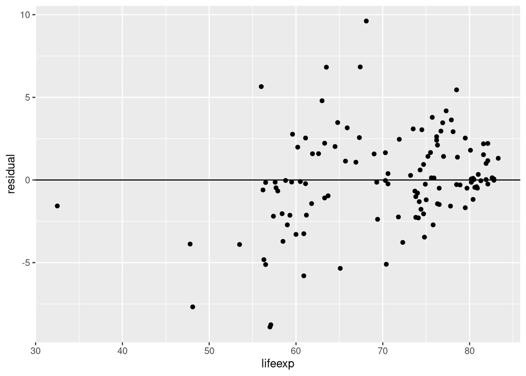

```r
points2 <- get_regression_points(model2)
ggplot(data = points2, mapping = aes(lifeexp, residual)) + geom_point() + geom_hline(yintercept = 0)
```

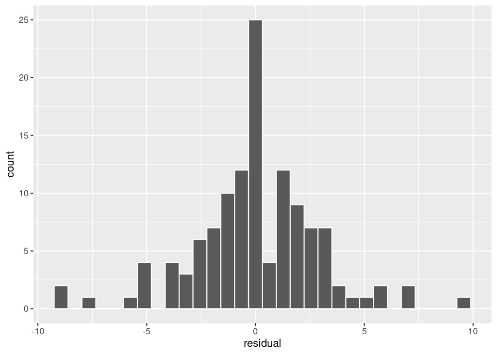

```r
ggplot(data = points2, mapping = aes(residual)) + geom_histogram(color = "white")
```

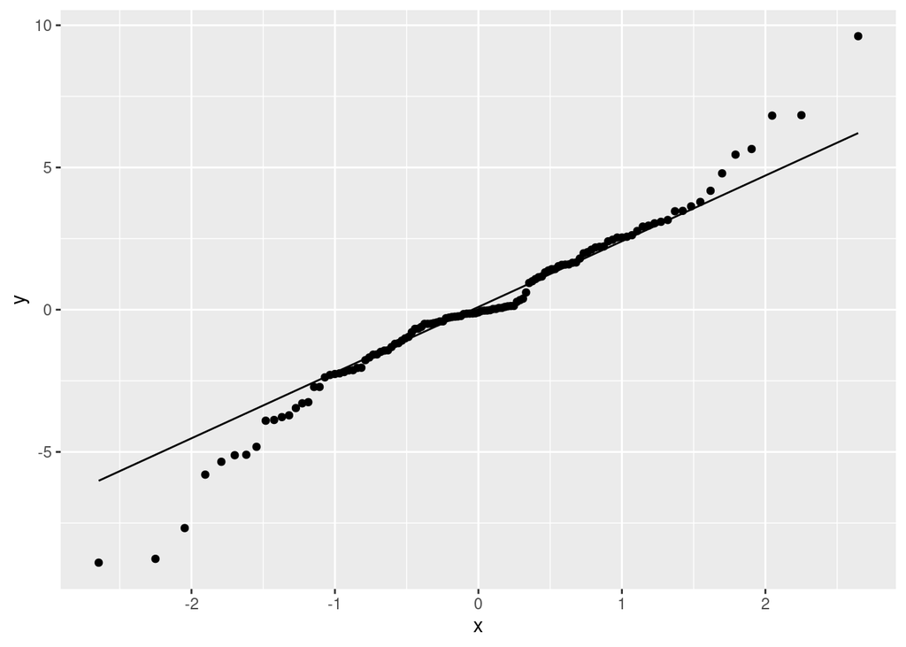

```r
ggplot(data = points2, aes(sample = residual)) + stat_qq() + stat_qq_line()
```

- Attempt 8: Since we created the new rows, we tried combining them into the regression model by using them as predictors but with no interaction in the model at first which meant that the lm model was “income+income_level+healthspend+gdpcapita+amountchildren+childmort+mort_level+chdperwoman+water”. This was not an ideal model as most of the p-values remained insignificant with many residuals being far from 0 and only 2 p-values being significant which were water (0.017) and childmort (0). R^2 was 0.896.
- Attempt 9: Trying interaction betweem terms, we decided to test how healthspend and gdpcapita would interact with each other seeing that previously, they had a high correlation with each other. This resulted in a much better histogram with most values being centered or near 0 and R^2 improved to 0.899. Now there were 3 significant p-values with gdpcapita (0.036), amountchildren: 4 being almost significant though at (0.085), childmort (0), and water (0.016).
- Attempt 10: Now, we want to increase interaction between like terms so now we looked at the interaction between income and income_level. However, this resulted in fewer p-values being significant with only water (0.025) and childmort (0). R^2 was 0.9 and the p-value was 0.
- Attempt 11: Due to the last result, we now tested 2 different terms which were slightly related previously and instead of chdperwoman interacting with childmort, we decided to test “amountchildren*childmort”. This significantly improved the histogram with many of the results being centered around 0 with only a few outliers in terms of the residuals with the R^2 being 0.92 with a p-value of 0. However, this resulted with only 1 significant p-value with water (0.006)
- Attempt 12: Now, we tried increasing interaction with our final fix of increasing interaction between most terms: “income*income_level+healthspend*gdpcapita+amountchildren*childmort+mort_level*chdperwoman+water”. This resulted in our highest R^2 at 0.922 and with a p-value of 0. Furthermore, multiple terms were significant with income (0.05), gdpcapita almost significant (0.068), water (0.005) and childmort almost significant (0.096).
- Attempt 13: There seemed to be a lot of collinearity in the model due to the amount of correlation we tried to test out within each interaction term. Thus, in order to have better p-values for most terms, we trimmed down the model to “income*income_level+healthspend*gdpcapita+childmort*chdperwoman+water”. Doing this resulted in a very large amount of residuals being centered around 0 with a R^2 of 0.91 and a p-value of 0. Furthermore, we now had more significant p-values with gdpcapita (0.043), childmort (0), chdperwoman (0.042), and water (0.004). The interaction term between childmort and chdperwoman also was significant at a p-value of (0).

## EXPLANATIONS (for the final model)

#2 - Does multi-collinearity exist?

```r
vif(model2)
```

```
## there are higher-order terms (interactions) in this model
## consider setting type = 'predictor'; see ?vif
```

```
##                               GVIF Df GVIF^(1/(2*Df))
## income                6.247234e+01  1        7.903944
## income_level          7.661994e+05  3        9.565852
## healthspend           5.505048e+01  1        7.419601
## gdpcapita             5.679807e+01  1        7.536449
## childmort             2.113404e+01  1        4.597177
## chdperwoman           1.134011e+01  1        3.367507
## water                 6.371843e+00  1        2.524251
## income:income_level   1.389771e+06  3       10.563891
## healthspend:gdpcapita 7.794679e+01  1        8.828748
## childmort:chdperwoman 3.197508e+01  1        5.654651
```

As we can see, multi-collinearity does exist in our final model as the VIF values tend to be greater than 5 for a lot of the individual variables. We can also confirm that multi-collinearity exists based on the correlation matrix (correlation_matrix2 as created above).

#3 - Explain the outliers. Our final model has a normal distribution for the most part (no serious deviation that needs to be noted). However, there are 2-4 significant outliers that can be seen both in the graph and the qq plot.